# Querying, Aggregating, and Exploring PORTAL Freeway Data

Bryan Blanc

2015-10-01

The purpose of this vignette is to provide examples of how to use `portalr` to query, aggregate and explore freeway data from PORTAL, Portland’s regional transportation data archive.

## Querying

Analysts can used the `freewayData()` function to request data for one or more detectors over a range of time.

Before you can query the database, you must create a database connection object, as demonstrated below. This step requires the use of a file called ‘db_credentials.json’, which contains your database authentication information.

```r
#Package imports
require(portalr)
require(rjson)
require(DBI)
require(RPostgreSQL)
require(plyr)

db_cred = fromJSON(file="db_credentials.json")
con <- dbConnect(dbDriver("PostgreSQL"),
                 host=db_cred$db_credentials$db_host,
                 port= 5432,
                 user=db_cred$db_credentials$db_user,
                 password = db_cred$db_credentials$db_pass,
                 dbname=db_cred$db_credentials$db_name)
#Initialize some metadata
detectors = dbGetQuery(con,"SELECT * FROM public.detectors")
stations= dbGetQuery(con,"SELECT * FROM public.stations")
```

After creating the database connection object, you can begin to start querying data. There are three parameters used to create a basic PORTAL query using `portalr`:

- Detector IDs (`dets`): A vector of detector IDs for which you would like to query data. These can be found within the PORTAL station metadata.
- Start Time (`startTime`): A string indicating what date/time to begin your query in the YYYY-MM-DD or YYYY-MM-DD HH:MM:SS formats.
- End Time (`endTime`): A string indicating what date/time to end your query in the YYYY-MM-DD or YYYY-MM-DD HH:MM:SS formats.

An example query is demonstrated below, and `head()` is used to display the first few rows of the table.

```r
#I-205 SB @ Clackamas Hwy
stas = c(1100)
dets = detectors$detectorid[detectors$stationid %in% stas]
data = freewayData(con = con, dets = dets , startTime = '2015-07-06',endTime = '2015-07-10')
head(data)
```

```
##             starttime volume speed occupancy detectorid
## 1 2015-07-06 00:01:40      1    74         0     100978
## 2 2015-07-06 00:01:20      1    50         1     100978
## 3 2015-07-06 00:01:00      1    50         1     100978
## 4 2015-07-06 00:00:40      2    58         2     100978
## 5 2015-07-06 00:00:20      2    50         2     100978
## 6 2015-07-06 00:00:00      0     0         0     100978
```

Typically, this very fine resolution of data (20-second) is not that useful to transportation analysts. That’s why the next step we’re going to talk about is aggregation.

## Aggregating

Analysts can use the `aggTime()` function to aggregate data to some resolution of time more useful than 20-second. A few examples are given below.

I want to separate by lane number in my aggregation, so I can join lanenumber in from the ‘detectors’ table in the ‘public’ schema of PORTAL.

```r
joined = join(data,detectors, by="detectorid")
agg = aggTime(unAgg=joined,aggVars = "lanenumber",timeCut = "15 min",acrossDays= FALSE)
head(agg)
```

```
##   lanenumber              period volume  occupancy    speed
## 1          1 2015-07-06 00:00:00     24 0.11111111 74.00000
## 2          1 2015-07-06 00:15:00     18 0.02222222 49.33333
## 3          1 2015-07-06 00:30:00     18 0.02222222 53.44444
## 4          1 2015-07-06 00:45:00     16 0.00000000 69.37500
## 5          1 2015-07-06 01:00:00     13 0.05128205 58.92308
## 6          1 2015-07-06 01:15:00      8 0.05128205 64.75000
```

In the below aggregation, I am going to cut the data by hour, and than aggregate it by hour of day across all the days in the dataset.

```r
agg_hod = aggTime(unAgg=joined,aggVars = "lanenumber",timeCut = "1 hour",acrossDays = TRUE)
head(agg_hod)
```

```
##   lanenumber                time volume   occupancy    speed
## 1          1 2015-10-01 00:00:00   83.8 0.095432099 67.05967
## 2          1 2015-10-01 01:00:00   36.4 0.028182205 66.69231
## 3          1 2015-10-01 02:00:00   20.4 0.002425044 65.56863
## 4          1 2015-10-01 03:00:00   33.2 0.015193312 65.09639
## 5          1 2015-10-01 04:00:00  127.4 0.192000066 67.75510
## 6          1 2015-10-01 05:00:00  499.4 1.568012390 72.30877
```

## Visualizing

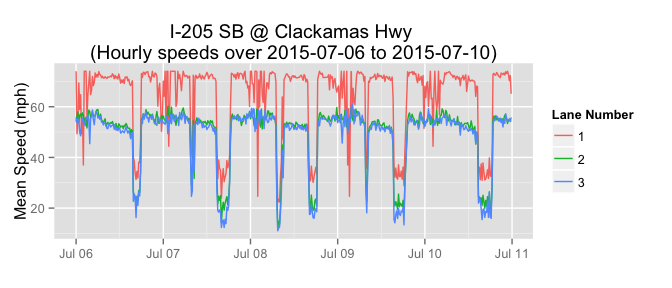

```r
require(ggplot2)
#Lane number needs to be converted from integer to factor for plotting
agg$lanenumber = factor(agg$lanenumber)
ggplot(agg,aes(x=period,y=speed,group =lanenumber, colour = lanenumber))+
  geom_line()+scale_colour_discrete(name="Lane Number")+
  scale_x_datetime()+
  ggtitle("I-205 SB @ Clackamas Hwy \n(Hourly speeds over 2015-07-06 to 2015-07-10)")+
  ylab("Mean Speed (mph)")+xlab("")
```

I can visualize the hour of day graph using ggplot and setting up a few of the labels.

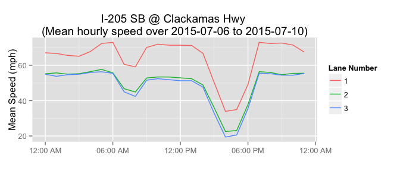

```r
require(ggplot2)
require(scales)
#Lane number needs to be converted from integer to factor for plotting
agg_hod$lanenumber = factor(agg_hod$lanenumber)

ggplot(agg_hod,aes(x=time,y=speed,group =lanenumber, colour = lanenumber))+
  geom_line()+scale_colour_discrete(name="Lane Number")+
  ggtitle("I-205 SB @ Clackamas Hwy \n(Mean hourly speed over 2015-07-06 to 2015-07-10)")+
  ylab("Mean Speed (mph)")+xlab("")+
  scale_x_datetime(labels = date_format("%I:%M %p", tz=Sys.timezone()))
```

## Last Steps

Always close all your connections when you are done.

```r
dbDisconnect(con)
```

```
## [1] TRUE
```